# Assignment 2: Path Analysis

Rushabh Barbhaya

2021-01-05

# Path Analysis Assignment

The included dataset (assignment2_data.csv) includes many demographic and motivational variables predicting student’s withdrawal rates for their first year of college. You will set up and test a path model predicting withdrawal for students.

Some example ideas:

- Demographics > satisfaction or commitment > intentions to quit > withdrawal
- Demographics > student success > intentions to quit > withdrawal
- Demographics > semester or career goals > intentions to quit > withdrawal
- Other combinations of included variables. Try at least four variables predicting withdrawal with at least 3 points (something > something > withdrawal - they cannot all predict withdrawal separately).

## Variables:

- Subject number
- Age
- ACT self-report
- Gender (1 = male, 2 = female)
- Declared a major (0 = no, 1 = yes)
- High School GPA
- Married (0 = no, 1 = yes, exclude the 3s)
- Instate/out (0 = outstate, 1 = instate, exclude the 3s)
- Class Year (freshman through senior+)
- Campus Job (0 = no, 1 = yes)
- Academic scholarship (0 = no, 1 = yes)
- Other scholarship (0 = no, 1 = yes)
- Number of older siblings
- Number of younger siblings
- Parents married (no, yes, divorces)
- Combined parent income (keep as continuous, ranges from 15K to 200K)
- Father education (keep as continuous, ranges from some high school to Ph.D.)
- Mother education (keep as continuous, ranges from some high school to Ph.D.)
- Academic Self Efficacy
- Intrinsic Motivation
- Integration
- Identification
- Introjection
- External Regulation
- Amotivation
- Relative Autonomy
- Affective commitment + Calculative Commitment
- Search Behavours + Intent to Search + Intent to Quit
- Satisfaction with MSU + Satisfaction Extra Curriculars
- Hours attempted semester 1
- Hours completed semester 1
- SEM GPA semester 1
- Cumulative GPA semester 1
- Withdrawal (THE DV!, 0 - stayed, 1 - withdrew, exclude all others)
- Semester goals - a combination of goals about the student’s semester
- Career goals - a combination of goals about the student’s career path

Load the libraries and dataset below.

```r
library(lavaan)
library(semPlot)
library(dplyr)

data = read.csv('assignment2_data.csv')
```

## Data Reduction

Subset the data to include only the variables you are interested in using.

```r
dataset = data[, c(2, 4, 6, 8, 11, 12, 15, 19, 20, 24, 26, 28, 32, 34)]
dataset = dataset %>%
  filter(stateres != 3)
# dataset = droplevels(dataset)
summary(dataset)
```

```
##       Age            gender          HSGPA          stateres
##  Min.   :17.00   Min.   :1.000   Min.   :2.000   Min.   :0.0000
##  1st Qu.:18.00   1st Qu.:1.000   1st Qu.:3.300   1st Qu.:1.0000
##  Median :18.00   Median :2.000   Median :3.600   Median :1.0000
##  Mean   :19.03   Mean   :1.591   Mean   :3.555   Mean   :0.9291
##  3rd Qu.:19.00   3rd Qu.:2.000   3rd Qu.:3.870   3rd Qu.:1.0000
##  Max.   :50.00   Max.   :2.000   Max.   :4.890   Max.   :2.0000
##
##     acdschol        scholother      pardivorced     SE_ACADEMIC1
##  Min.   :0.0000   Min.   :0.0000   Min.   :1.000   Min.   :2.286
##  1st Qu.:0.0000   1st Qu.:0.0000   1st Qu.:2.000   1st Qu.:4.143
##  Median :0.0000   Median :0.0000   Median :2.000   Median :4.714
##  Mean   :0.3823   Mean   :0.2248   Mean   :2.181   Mean   :4.669
##  3rd Qu.:1.0000   3rd Qu.:0.0000   3rd Qu.:2.000   3rd Qu.:5.143
##  Max.   :1.0000   Max.   :1.0000   Max.   :3.000   Max.   :7.000
##  NA's   :9        NA's   :18       NA's   :23      NA's   :5
##     SD_INT1        SD_EXTREG1      SD_RELAUT1     INTENTIONS_Combine
##  Min.   :1.000   Min.   :1.000   Min.   :-15.00   Min.   : 3.000
##  1st Qu.:4.000   1st Qu.:2.667   1st Qu.:  6.00   1st Qu.: 4.500
##  Median :4.667   Median :4.000   Median : 12.67   Median : 6.250
##  Mean   :4.637   Mean   :3.835   Mean   : 12.99   Mean   : 6.639
##  3rd Qu.:5.333   3rd Qu.:5.000   3rd Qu.: 20.33   3rd Qu.: 8.000
##  Max.   :7.000   Max.   :7.000   Max.   : 36.00   Max.   :15.000
##  NA's   :6       NA's   :6       NA's   :5        NA's   :207
##   SEM_GPA_SEM1   WITHDRAWAL_SEM2
##  Min.   :0.000   Min.   :0.0000
##  1st Qu.:2.500   1st Qu.:0.0000
##  Median :3.140   Median :0.0000
##  Mean   :2.907   Mean   :0.2318
##  3rd Qu.:3.610   3rd Qu.:0.0000
##  Max.   :4.000   Max.   :2.0000
##  NA's   :18      NA's   :46
```

## Short Data Screening

### Accuracy

We can assume the data is mostly accurate. You should first exclude the precollege students from the withdrawal variable (i.e., anything not 0 or 1).

```r
dataset = dataset %>%
  filter(WITHDRAWAL_SEM2 != 2)
# dataset = droplevels(dataset)
summary(dataset)
```

```
##       Age            gender          HSGPA          stateres
##  Min.   :17.00   Min.   :1.000   Min.   :2.000   Min.   :0.0000
##  1st Qu.:18.00   1st Qu.:1.000   1st Qu.:3.300   1st Qu.:1.0000
##  Median :18.00   Median :2.000   Median :3.600   Median :1.0000
##  Mean   :18.93   Mean   :1.603   Mean   :3.556   Mean   :0.9301
##  3rd Qu.:19.00   3rd Qu.:2.000   3rd Qu.:3.870   3rd Qu.:1.0000
##  Max.   :50.00   Max.   :2.000   Max.   :4.890   Max.   :2.0000
##
##     acdschol        scholother      pardivorced     SE_ACADEMIC1
##  Min.   :0.0000   Min.   :0.0000   Min.   :1.000   Min.   :2.286
##  1st Qu.:0.0000   1st Qu.:0.0000   1st Qu.:2.000   1st Qu.:4.143
##  Median :0.0000   Median :0.0000   Median :2.000   Median :4.714
##  Mean   :0.3927   Mean   :0.2345   Mean   :2.169   Mean   :4.667
##  3rd Qu.:1.0000   3rd Qu.:0.0000   3rd Qu.:2.000   3rd Qu.:5.143
##  Max.   :1.0000   Max.   :1.0000   Max.   :3.000   Max.   :7.000
##  NA's   :9        NA's   :18       NA's   :22      NA's   :5
##     SD_INT1        SD_EXTREG1      SD_RELAUT1     INTENTIONS_Combine
##  Min.   :1.000   Min.   :1.000   Min.   :-15.00   Min.   : 3.000
##  1st Qu.:4.000   1st Qu.:2.667   1st Qu.:  6.00   1st Qu.: 4.500
##  Median :4.667   Median :4.000   Median : 12.67   Median : 6.250
##  Mean   :4.664   Mean   :3.833   Mean   : 13.13   Mean   : 6.620
##  3rd Qu.:5.333   3rd Qu.:5.000   3rd Qu.: 20.67   3rd Qu.: 7.917
##  Max.   :7.000   Max.   :7.000   Max.   : 36.00   Max.   :15.000
##  NA's   :6       NA's   :6       NA's   :5        NA's   :172
##   SEM_GPA_SEM1   WITHDRAWAL_SEM2
##  Min.   :0.000   Min.   :0.000
##  1st Qu.:2.538   1st Qu.:0.000
##  Median :3.150   Median :0.000
##  Mean   :2.932   Mean   :0.226
##  3rd Qu.:3.612   3rd Qu.:0.000
##  Max.   :4.000   Max.   :1.000
##  NA's   :3
```

### Missing data

Because we are using a small number of variables, we will not have any missing data to replace. You should exclude participants with any missing data.

```r
#summary(data)
noMiss = na.omit(dataset)
summary(noMiss)
```

```
##       Age            gender          HSGPA          stateres
##  Min.   :17.00   Min.   :1.000   Min.   :2.000   Min.   :0.0000
##  1st Qu.:18.00   1st Qu.:1.000   1st Qu.:3.365   1st Qu.:1.0000
##  Median :18.00   Median :2.000   Median :3.600   Median :1.0000
##  Mean   :18.89   Mean   :1.628   Mean   :3.588   Mean   :0.9367
##  3rd Qu.:19.00   3rd Qu.:2.000   3rd Qu.:3.900   3rd Qu.:1.0000
##  Max.   :45.00   Max.   :2.000   Max.   :4.800   Max.   :2.0000
##     acdschol        scholother      pardivorced    SE_ACADEMIC1
##  Min.   :0.0000   Min.   :0.0000   Min.   :1.00   Min.   :2.286
##  1st Qu.:0.0000   1st Qu.:0.0000   1st Qu.:2.00   1st Qu.:4.143
##  Median :0.0000   Median :0.0000   Median :2.00   Median :4.714
##  Mean   :0.4209   Mean   :0.2603   Mean   :2.17   Mean   :4.678
##  3rd Qu.:1.0000   3rd Qu.:1.0000   3rd Qu.:2.00   3rd Qu.:5.143
##  Max.   :1.0000   Max.   :1.0000   Max.   :3.00   Max.   :7.000
##     SD_INT1        SD_EXTREG1      SD_RELAUT1     INTENTIONS_Combine
##  Min.   :1.000   Min.   :1.000   Min.   :-15.00   Min.   : 3.000
##  1st Qu.:4.000   1st Qu.:2.667   1st Qu.:  6.00   1st Qu.: 4.500
##  Median :4.667   Median :4.000   Median : 12.67   Median : 6.250
##  Mean   :4.593   Mean   :3.868   Mean   : 12.84   Mean   : 6.632
##  3rd Qu.:5.333   3rd Qu.:5.000   3rd Qu.: 20.00   3rd Qu.: 7.917
##  Max.   :7.000   Max.   :7.000   Max.   : 35.67   Max.   :15.000
##   SEM_GPA_SEM1   WITHDRAWAL_SEM2
##  Min.   :0.000   Min.   :0.0000
##  1st Qu.:2.670   1st Qu.:0.0000
##  Median :3.270   Median :0.0000
##  Mean   :3.095   Mean   :0.1849
##  3rd Qu.:3.705   3rd Qu.:0.0000
##  Max.   :4.000   Max.   :1.0000
```

### Outliers

- Create the Mahalanobis distance scores.
- Create a table of the number of outliers you have.
- Exclude all multivariate outliers.

QUESTION: Looking at your final sample size, do you think you have an adequate sample for your model? ANSWER: There are 408 samples. More samples would have been better as they account for all the possible combinations in the dataset.

## Build Your Model

Using lavaan syntax, build the model of your prediction for withdrawal.

```r
mahal = mahalanobis(noMiss[, -1],
                    colMeans(noMiss[, -1], na.rm = T),
                    cov(noMiss[, -1]), use = "pairwise.complete.obs")
ncol(noMiss[, -1])
```

```
## [1] 13
```

```r
cutoff = qchisq(1-.001, ncol(noMiss[, -1]))
cutoff
```

```
## [1] 34.52818
```

```r
table(mahal < cutoff)
```

```
##
## FALSE  TRUE
##     3   408
```

```r
noOut = subset(noMiss, mahal < cutoff)
summary(noOut)
```

```
##       Age            gender          HSGPA          stateres
##  Min.   :17.00   Min.   :1.000   Min.   :2.200   Min.   :0.0000
##  1st Qu.:18.00   1st Qu.:1.000   1st Qu.:3.397   1st Qu.:1.0000
##  Median :18.00   Median :2.000   Median :3.650   Median :1.0000
##  Mean   :18.89   Mean   :1.627   Mean   :3.593   Mean   :0.9387
##  3rd Qu.:19.00   3rd Qu.:2.000   3rd Qu.:3.900   3rd Qu.:1.0000
##  Max.   :45.00   Max.   :2.000   Max.   :4.800   Max.   :2.0000
##     acdschol        scholother      pardivorced     SE_ACADEMIC1
##  Min.   :0.0000   Min.   :0.0000   Min.   :1.000   Min.   :2.286
##  1st Qu.:0.0000   1st Qu.:0.0000   1st Qu.:2.000   1st Qu.:4.143
##  Median :0.0000   Median :0.0000   Median :2.000   Median :4.714
##  Mean   :0.4216   Mean   :0.2598   Mean   :2.169   Mean   :4.676
##  3rd Qu.:1.0000   3rd Qu.:1.0000   3rd Qu.:2.000   3rd Qu.:5.143
##  Max.   :1.0000   Max.   :1.0000   Max.   :3.000   Max.   :7.000
##     SD_INT1        SD_EXTREG1      SD_RELAUT1     INTENTIONS_Combine
##  Min.   :1.000   Min.   :1.000   Min.   :-15.00   Min.   : 3.000
##  1st Qu.:4.000   1st Qu.:2.667   1st Qu.:  6.00   1st Qu.: 4.562
##  Median :4.667   Median :4.000   Median : 12.67   Median : 6.250
##  Mean   :4.585   Mean   :3.867   Mean   : 12.84   Mean   : 6.645
##  3rd Qu.:5.333   3rd Qu.:5.000   3rd Qu.: 20.00   3rd Qu.: 7.938
##  Max.   :7.000   Max.   :7.000   Max.   : 35.67   Max.   :15.000
##   SEM_GPA_SEM1   WITHDRAWAL_SEM2
##  Min.   :0.000   Min.   :0.0000
##  1st Qu.:2.678   1st Qu.:0.0000
##  Median :3.270   Median :0.0000
##  Mean   :3.110   Mean   :0.1838
##  3rd Qu.:3.710   3rd Qu.:0.0000
##  Max.   :4.000   Max.   :1.0000
```

QUESTION: What are the total number of parameters you could estimate given the number of measured variables in your model? ANSWER: 33 free parameters

QUESTION: What are the parameters that you are going to estimate? List them out below. ANSWER: Age, Gender, HighSchool GPA, In/Outstate, academic scholarship, other scholarships, parents married, Academic Self Efficacy, Intrinsic Motivation, External Regulation, Relative Autonomy, Intent to Quit, SEM GPA semester 1, Withdrawal flag

## Analyze Your Model

Use the `sem()` function to analyze your model.

```r
model.cor = cor(noOut)
model.cor
```

```
##                            Age        gender       HSGPA    stateres
## Age                 1.00000000 -0.1496652581 -0.09239171 -0.04922029
## gender             -0.14966526  1.0000000000  0.20974601 -0.02478087
## HSGPA              -0.09239171  0.2097460081  1.00000000 -0.07177522
## stateres           -0.04922029 -0.0247808723 -0.07177522  1.00000000
## acdschol           -0.12112402  0.0829325848  0.59845942 -0.13779010
## scholother         -0.09147911  0.0634672729  0.17792406 -0.01050036
## pardivorced         0.04613657  0.0410796576 -0.01734037 -0.01539646
## SE_ACADEMIC1        0.04543864 -0.0648706301  0.24280939  0.11517751
## SD_INT1            -0.04882828  0.2387993968  0.07876269  0.11224447
## SD_EXTREG1         -0.00828428 -0.2352978890  0.01132277 -0.05123165
## SD_RELAUT1         -0.02795602  0.2658671897  0.05767268  0.09578305
## INTENTIONS_Combine  0.01768799  0.0412088279 -0.07896781 -0.18443981
## SEM_GPA_SEM1        0.02760613  0.1529495684  0.50378560 -0.09912451
## WITHDRAWAL_SEM2     0.07921380 -0.0007698688 -0.10325728 -0.12724755
##                        acdschol   scholother  pardivorced SE_ACADEMIC1
## Age                -0.121124016 -0.091479114  0.046136570   0.04543864
## gender              0.082932585  0.063467273  0.041079658  -0.06487063
## HSGPA               0.598459416  0.177924060 -0.017340371   0.24280939
## stateres           -0.137790095 -0.010500365 -0.015396462   0.11517751
## acdschol            1.000000000  0.139371188 -0.076929846   0.20886895
## scholother          0.139371188  1.000000000 -0.023544146   0.07461657
## pardivorced        -0.076929846 -0.023544146  1.000000000  -0.01969630
## SE_ACADEMIC1        0.208868951  0.074616573 -0.019696297   1.00000000
## SD_INT1             0.066919792 -0.003096002 -0.020709235   0.23228847
## SD_EXTREG1          0.005059422  0.024583424 -0.006295041  -0.01155105
## SD_RELAUT1          0.058891887  0.015406461 -0.003495904   0.24092692
## INTENTIONS_Combine -0.066500567 -0.051476503 -0.057347113  -0.05980910
## SEM_GPA_SEM1        0.434096235  0.135930281 -0.090225775   0.22305060
## WITHDRAWAL_SEM2    -0.097613085  0.007426944  0.045884061  -0.06348559
##                         SD_INT1   SD_EXTREG1   SD_RELAUT1 INTENTIONS_Combine
## Age                -0.048828280 -0.008284280 -0.027956018         0.01768799
## gender              0.238799397 -0.235297889  0.265867190         0.04120883
## HSGPA               0.078762692  0.011322775  0.057672682        -0.07896781
## stateres            0.112244474 -0.051231654  0.095783049        -0.18443981
## acdschol            0.066919792  0.005059422  0.058891887        -0.06650057
## scholother         -0.003096002  0.024583424  0.015406461        -0.05147650
## pardivorced        -0.020709235 -0.006295041 -0.003495904        -0.05734711
## SE_ACADEMIC1        0.232288471 -0.011551045  0.240926917        -0.05980910
## SD_INT1             1.000000000 -0.398879105  0.811513287        -0.08870477
## SD_EXTREG1         -0.398879105  1.000000000 -0.707189028         0.11853015
## SD_RELAUT1          0.811513287 -0.707189028  1.000000000        -0.14216002
## INTENTIONS_Combine -0.088704765  0.118530147 -0.142160022         1.00000000
## SEM_GPA_SEM1        0.067744576  0.023237933  0.053620560        -0.05150677
## WITHDRAWAL_SEM2     0.030167996 -0.056130198  0.018916933         0.38979116
##                    SEM_GPA_SEM1 WITHDRAWAL_SEM2
## Age                  0.02760613    0.0792138033
## gender               0.15294957   -0.0007698688
## HSGPA                0.50378560   -0.1032572825
## stateres            -0.09912451   -0.1272475478
## acdschol             0.43409623   -0.0976130846
## scholother           0.13593028    0.0074269439
## pardivorced         -0.09022577    0.0458840610
## SE_ACADEMIC1         0.22305060   -0.0634855936
## SD_INT1              0.06774458    0.0301679964
## SD_EXTREG1           0.02323793   -0.0561301975
## SD_RELAUT1           0.05362056    0.0189169326
## INTENTIONS_Combine  -0.05150677    0.3897911626
## SEM_GPA_SEM1         1.00000000   -0.2301031769
## WITHDRAWAL_SEM2     -0.23010318    1.0000000000
```

```r
model = '
Demo =~ Age + gender + stateres + pardivorced
StuSuccess =~ HSGPA + acdschol + scholother + SE_ACADEMIC1 + SEM_GPA_SEM1
IntQuit =~ SD_INT1 + SD_EXTREG1 + SD_RELAUT1 + INTENTIONS_Combine
WITHDRAWAL_SEM2 ~ Demo + StuSuccess + IntQuit
'
model.fit = sem(model, data = model.cor)
```

## Summarize Your Model

Include a `summary()` of your model with the standardized output, fit.measures, and rsquare options.

```r
summary(model.fit, standardized = T, fit.measures = T, rsquare = T)
```

```
## lavaan 0.6-7 ended normally after 161 iterations
##
##   Estimator                                         ML
##   Optimization method                           NLMINB
##   Number of free parameters                         33
##
##   Number of observations                            14
##
## Model Test User Model:
##
##   Test statistic                               523.460
##   Degrees of freedom                                72
##   P-value (Chi-square)                           0.000
##
## Model Test Baseline Model:
##
##   Test statistic                               656.933
##   Degrees of freedom                                91
##   P-value                                        0.000
##
## User Model versus Baseline Model:
##
##   Comparative Fit Index (CFI)                    0.202
##   Tucker-Lewis Index (TLI)                      -0.008
##
## Loglikelihood and Information Criteria:
##
##   Loglikelihood user model (H0)                 25.234
##   Loglikelihood unrestricted model (H1)        286.964
##
##   Akaike (AIC)                                  15.531
##   Bayesian (BIC)                                36.620
##   Sample-size adjusted Bayesian (BIC)          -63.849
##
## Root Mean Square Error of Approximation:
##
##   RMSEA                                          0.669
##   90 Percent confidence interval - lower         0.616
##   90 Percent confidence interval - upper         0.724
##   P-value RMSEA <= 0.05                          0.000
```

[output cut: 66 more lines]

```
##                    Estimate
##     Age              -0.068
##     gender           -0.006
##     stateres         -0.186
##     pardivorced      -0.041
##     HSGPA             0.877
##     acdschol          0.841
##     scholother        0.082
##     SE_ACADEMIC1      0.113
##     SEM_GPA_SEM1      0.711
##     SD_INT1           0.802
##     SD_EXTREG1        0.771
##     SD_RELAUT1           NA
##     INTENTIONS_Cmb    0.110
##     WITHDRAWAL_SEM   -0.023
```

## Diagram Your Model

Include a diagram of your model with `par` estimates and increasing the font size for the labels.

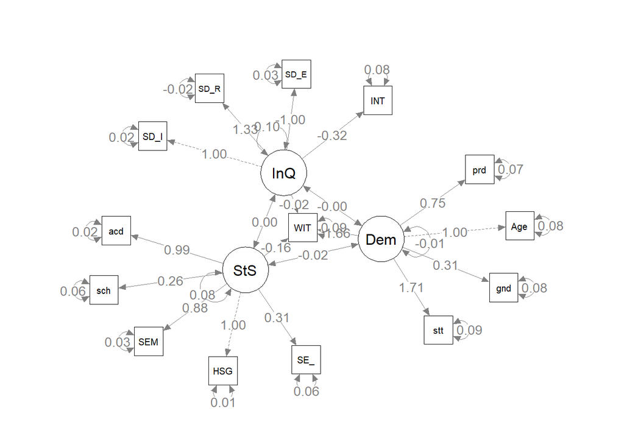

```r
semPaths(model.fit, whatLabels = "par", edge.label.cex = 1, layout = "spring")
```

## Model Improvement

Create a second model that either deletes a path in the original model or adds a new potential path to the model (just one path, no new variables!).

```r
model2.cor = cor(noOut[,-c(7)])
model2.cor
```

```
##                            Age        gender       HSGPA    stateres
## Age                 1.00000000 -0.1496652581 -0.09239171 -0.04922029
## gender             -0.14966526  1.0000000000  0.20974601 -0.02478087
## HSGPA              -0.09239171  0.2097460081  1.00000000 -0.07177522
## stateres           -0.04922029 -0.0247808723 -0.07177522  1.00000000
## acdschol           -0.12112402  0.0829325848  0.59845942 -0.13779010
## scholother         -0.09147911  0.0634672729  0.17792406 -0.01050036
## SE_ACADEMIC1        0.04543864 -0.0648706301  0.24280939  0.11517751
## SD_INT1            -0.04882828  0.2387993968  0.07876269  0.11224447
## SD_EXTREG1         -0.00828428 -0.2352978890  0.01132277 -0.05123165
## SD_RELAUT1         -0.02795602  0.2658671897  0.05767268  0.09578305
## INTENTIONS_Combine  0.01768799  0.0412088279 -0.07896781 -0.18443981
## SEM_GPA_SEM1        0.02760613  0.1529495684  0.50378560 -0.09912451
## WITHDRAWAL_SEM2     0.07921380 -0.0007698688 -0.10325728 -0.12724755
##                        acdschol   scholother SE_ACADEMIC1      SD_INT1
## Age                -0.121124016 -0.091479114   0.04543864 -0.048828280
## gender              0.082932585  0.063467273  -0.06487063  0.238799397
## HSGPA               0.598459416  0.177924060   0.24280939  0.078762692
## stateres           -0.137790095 -0.010500365   0.11517751  0.112244474
## acdschol            1.000000000  0.139371188   0.20886895  0.066919792
## scholother          0.139371188  1.000000000   0.07461657 -0.003096002
## SE_ACADEMIC1        0.208868951  0.074616573   1.00000000  0.232288471
## SD_INT1             0.066919792 -0.003096002   0.23228847  1.000000000
## SD_EXTREG1          0.005059422  0.024583424  -0.01155105 -0.398879105
## SD_RELAUT1          0.058891887  0.015406461   0.24092692  0.811513287
## INTENTIONS_Combine -0.066500567 -0.051476503  -0.05980910 -0.088704765
## SEM_GPA_SEM1        0.434096235  0.135930281   0.22305060  0.067744576
## WITHDRAWAL_SEM2    -0.097613085  0.007426944  -0.06348559  0.030167996
##                      SD_EXTREG1  SD_RELAUT1 INTENTIONS_Combine SEM_GPA_SEM1
## Age                -0.008284280 -0.02795602         0.01768799   0.02760613
## gender             -0.235297889  0.26586719         0.04120883   0.15294957
## HSGPA               0.011322775  0.05767268        -0.07896781   0.50378560
## stateres           -0.051231654  0.09578305        -0.18443981  -0.09912451
## acdschol            0.005059422  0.05889189        -0.06650057   0.43409623
## scholother          0.024583424  0.01540646        -0.05147650   0.13593028
## SE_ACADEMIC1       -0.011551045  0.24092692        -0.05980910   0.22305060
## SD_INT1            -0.398879105  0.81151329        -0.08870477   0.06774458
## SD_EXTREG1          1.000000000 -0.70718903         0.11853015   0.02323793
## SD_RELAUT1         -0.707189028  1.00000000        -0.14216002   0.05362056
## INTENTIONS_Combine  0.118530147 -0.14216002         1.00000000  -0.05150677
## SEM_GPA_SEM1        0.023237933  0.05362056        -0.05150677   1.00000000
## WITHDRAWAL_SEM2    -0.056130198  0.01891693         0.38979116  -0.23010318
##                    WITHDRAWAL_SEM2
## Age                   0.0792138033
## gender               -0.0007698688
## HSGPA                -0.1032572825
## stateres             -0.1272475478
## acdschol             -0.0976130846
## scholother            0.0074269439
## SE_ACADEMIC1         -0.0634855936
## SD_INT1               0.0301679964
## SD_EXTREG1           -0.0561301975
## SD_RELAUT1            0.0189169326
## INTENTIONS_Combine    0.3897911626
## SEM_GPA_SEM1         -0.2301031769
## WITHDRAWAL_SEM2       1.0000000000
```

```r
model2 = '
Demo =~ Age + gender + stateres
StuSuccess =~  HSGPA + acdschol + scholother + SE_ACADEMIC1 + SEM_GPA_SEM1
IntQuit =~ SD_INT1 + SD_EXTREG1 + SD_RELAUT1 + INTENTIONS_Combine
WITHDRAWAL_SEM2 ~ Demo + StuSuccess + IntQuit
'
model2.fit = sem(model2, data = model2.cor)
model3.cor = cor(noOut)
model3.cor
```

```
##                            Age        gender       HSGPA    stateres
## Age                 1.00000000 -0.1496652581 -0.09239171 -0.04922029
## gender             -0.14966526  1.0000000000  0.20974601 -0.02478087
## HSGPA              -0.09239171  0.2097460081  1.00000000 -0.07177522
## stateres           -0.04922029 -0.0247808723 -0.07177522  1.00000000
## acdschol           -0.12112402  0.0829325848  0.59845942 -0.13779010
## scholother         -0.09147911  0.0634672729  0.17792406 -0.01050036
## pardivorced         0.04613657  0.0410796576 -0.01734037 -0.01539646
## SE_ACADEMIC1        0.04543864 -0.0648706301  0.24280939  0.11517751
## SD_INT1            -0.04882828  0.2387993968  0.07876269  0.11224447
## SD_EXTREG1         -0.00828428 -0.2352978890  0.01132277 -0.05123165
## SD_RELAUT1         -0.02795602  0.2658671897  0.05767268  0.09578305
## INTENTIONS_Combine  0.01768799  0.0412088279 -0.07896781 -0.18443981
## SEM_GPA_SEM1        0.02760613  0.1529495684  0.50378560 -0.09912451
## WITHDRAWAL_SEM2     0.07921380 -0.0007698688 -0.10325728 -0.12724755
##                        acdschol   scholother  pardivorced SE_ACADEMIC1
## Age                -0.121124016 -0.091479114  0.046136570   0.04543864
## gender              0.082932585  0.063467273  0.041079658  -0.06487063
## HSGPA               0.598459416  0.177924060 -0.017340371   0.24280939
## stateres           -0.137790095 -0.010500365 -0.015396462   0.11517751
## acdschol            1.000000000  0.139371188 -0.076929846   0.20886895
## scholother          0.139371188  1.000000000 -0.023544146   0.07461657
## pardivorced        -0.076929846 -0.023544146  1.000000000  -0.01969630
## SE_ACADEMIC1        0.208868951  0.074616573 -0.019696297   1.00000000
## SD_INT1             0.066919792 -0.003096002 -0.020709235   0.23228847
## SD_EXTREG1          0.005059422  0.024583424 -0.006295041  -0.01155105
## SD_RELAUT1          0.058891887  0.015406461 -0.003495904   0.24092692
## INTENTIONS_Combine -0.066500567 -0.051476503 -0.057347113  -0.05980910
## SEM_GPA_SEM1        0.434096235  0.135930281 -0.090225775   0.22305060
## WITHDRAWAL_SEM2    -0.097613085  0.007426944  0.045884061  -0.06348559
##                         SD_INT1   SD_EXTREG1   SD_RELAUT1 INTENTIONS_Combine
## Age                -0.048828280 -0.008284280 -0.027956018         0.01768799
## gender              0.238799397 -0.235297889  0.265867190         0.04120883
## HSGPA               0.078762692  0.011322775  0.057672682        -0.07896781
## stateres            0.112244474 -0.051231654  0.095783049        -0.18443981
## acdschol            0.066919792  0.005059422  0.058891887        -0.06650057
## scholother         -0.003096002  0.024583424  0.015406461        -0.05147650
## pardivorced        -0.020709235 -0.006295041 -0.003495904        -0.05734711
## SE_ACADEMIC1        0.232288471 -0.011551045  0.240926917        -0.05980910
## SD_INT1             1.000000000 -0.398879105  0.811513287        -0.08870477
## SD_EXTREG1         -0.398879105  1.000000000 -0.707189028         0.11853015
## SD_RELAUT1          0.811513287 -0.707189028  1.000000000        -0.14216002
## INTENTIONS_Combine -0.088704765  0.118530147 -0.142160022         1.00000000
## SEM_GPA_SEM1        0.067744576  0.023237933  0.053620560        -0.05150677
## WITHDRAWAL_SEM2     0.030167996 -0.056130198  0.018916933         0.38979116
##                    SEM_GPA_SEM1 WITHDRAWAL_SEM2
## Age                  0.02760613    0.0792138033
## gender               0.15294957   -0.0007698688
## HSGPA                0.50378560   -0.1032572825
## stateres            -0.09912451   -0.1272475478
## acdschol             0.43409623   -0.0976130846
## scholother           0.13593028    0.0074269439
## pardivorced         -0.09022577    0.0458840610
## SE_ACADEMIC1         0.22305060   -0.0634855936
## SD_INT1              0.06774458    0.0301679964
## SD_EXTREG1           0.02323793   -0.0561301975
## SD_RELAUT1           0.05362056    0.0189169326
## INTENTIONS_Combine  -0.05150677    0.3897911626
## SEM_GPA_SEM1         1.00000000   -0.2301031769
## WITHDRAWAL_SEM2     -0.23010318    1.0000000000
```

```r
model3 = '
StuSuccess =~  HSGPA + acdschol + scholother + SE_ACADEMIC1 + SEM_GPA_SEM1
IntQuit =~ SD_INT1 + SD_EXTREG1 + SD_RELAUT1 + INTENTIONS_Combine
WITHDRAWAL_SEM2 ~ StuSuccess + IntQuit
'
model3.fit = sem(model3, data = model3.cor)
```

## Analyze, Summarize

Include the `sem()` and `summary()` functions in this section for your second model.

```r
summary(model2.fit, standardized = T, fit.measures = T, rsquare = T)
```

```
## lavaan 0.6-7 ended normally after 156 iterations
##
##   Estimator                                         ML
##   Optimization method                           NLMINB
##   Number of free parameters                         31
##
##   Number of observations                            13
##
## Model Test User Model:
##
##   Test statistic                               465.304
##   Degrees of freedom                                60
##   P-value (Chi-square)                           0.000
##
## Model Test Baseline Model:
##
##   Test statistic                               588.083
##   Degrees of freedom                                78
##   P-value                                        0.000
##
## User Model versus Baseline Model:
##
##   Comparative Fit Index (CFI)                    0.205
##   Tucker-Lewis Index (TLI)                      -0.033
##
## Loglikelihood and Information Criteria:
##
##   Loglikelihood user model (H0)                 19.209
##   Loglikelihood unrestricted model (H1)        251.861
##
##   Akaike (AIC)                                  23.582
##   Bayesian (BIC)                                41.096
##   Sample-size adjusted Bayesian (BIC)          -52.988
##
## Root Mean Square Error of Approximation:
##
##   RMSEA                                          0.721
##   90 Percent confidence interval - lower         0.661
##   90 Percent confidence interval - upper         0.783
##   P-value RMSEA <= 0.05                          0.000
```

[output cut: 63 more lines]

```
## R-Square:
##                    Estimate
##     Age              -0.123
##     gender           -0.017
##     stateres         -0.369
##     HSGPA             0.881
##     acdschol          0.833
##     scholother        0.070
##     SE_ACADEMIC1      0.096
##     SEM_GPA_SEM1      0.692
##     SD_INT1           0.806
##     SD_EXTREG1        0.779
##     SD_RELAUT1           NA
##     INTENTIONS_Cmb    0.116
##     WITHDRAWAL_SEM    0.053
```

```r
summary(model3.fit, standardized = T, fit.measures = T, rsquare = T)
```

```
## lavaan 0.6-7 ended normally after 100 iterations
##
##   Estimator                                         ML
##   Optimization method                           NLMINB
##   Number of free parameters                         22
##
##   Number of observations                            14
##
## Model Test User Model:
##
##   Test statistic                                19.724
##   Degrees of freedom                                33
##   P-value (Chi-square)                           0.967
##
## Model Test Baseline Model:
##
##   Test statistic                               143.039
##   Degrees of freedom                                45
##   P-value                                        0.000
##
## User Model versus Baseline Model:
##
##   Comparative Fit Index (CFI)                    1.000
##   Tucker-Lewis Index (TLI)                       1.185
##
## Loglikelihood and Information Criteria:
##
##   Loglikelihood user model (H0)                 27.255
##   Loglikelihood unrestricted model (H1)         37.117
##
##   Akaike (AIC)                                 -10.511
##   Bayesian (BIC)                                 3.549
##   Sample-size adjusted Bayesian (BIC)          -63.431
##
## Root Mean Square Error of Approximation:
##
##   RMSEA                                          0.000
##   90 Percent confidence interval - lower         0.000
##   90 Percent confidence interval - upper         0.000
##   P-value RMSEA <= 0.05                          0.975
```

[output cut: 48 more lines]

```
##     StuSuccess        0.087    0.037    2.372    0.018    1.000    1.000
##     IntQuit           0.100    0.044    2.267    0.023    1.000    1.000
##
## R-Square:
##                    Estimate
##     HSGPA             0.917
##     acdschol          0.820
##     scholother        0.070
##     SE_ACADEMIC1      0.123
##     SEM_GPA_SEM1      0.687
##     SD_INT1           0.846
##     SD_EXTREG1        0.804
##     SD_RELAUT1           NA
##     INTENTIONS_Cmb    0.105
##     WITHDRAWAL_SEM    0.265
```

## Diagram Your Model

Include a diagram of your model with `par` estimates and increasing the font size for the labels.

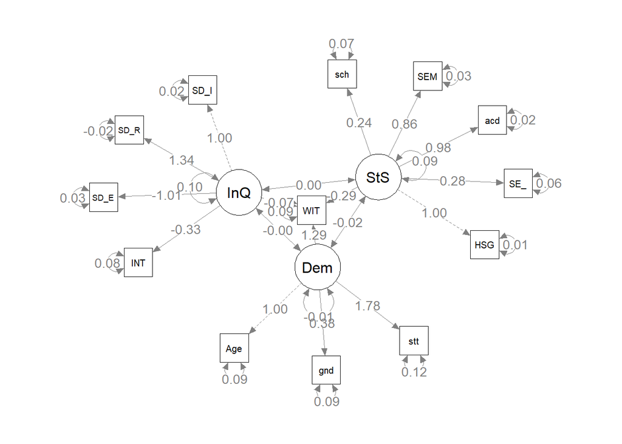

```r
semPaths(model2.fit, whatLabels = "par", edge.label.cex = 1, layout = "spring")
```

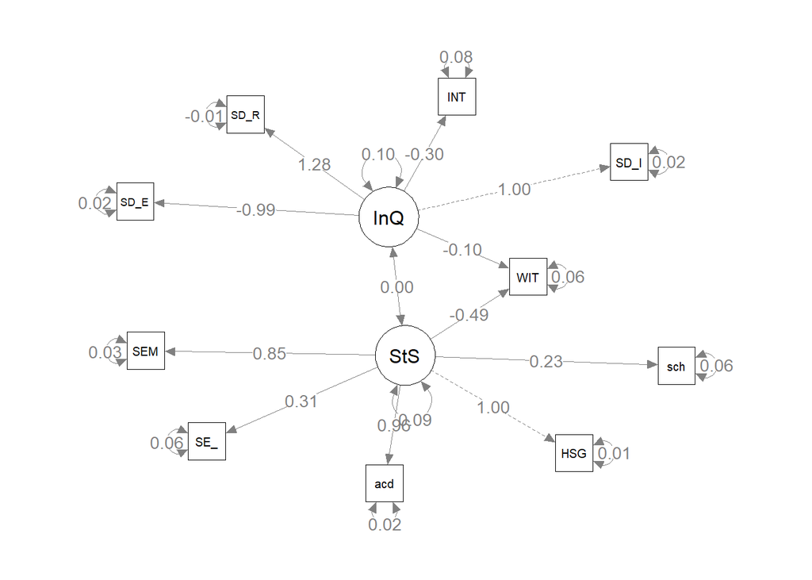

```r
semPaths(model3.fit, whatLabels = "par", edge.label.cex = 1, layout = "spring")
```

## Model Comparison

Compare your two models using the `anova()` function and the `aic` and `ecvi` fit measures.

```r
anova(model.fit, model2.fit)
```

```
## Chi-Squared Difference Test
##
##            Df    AIC    BIC  Chisq Chisq diff Df diff Pr(>Chisq)
## model2.fit 60 23.582 41.096 465.30
## model.fit  72 15.531 36.620 523.46     58.156      12  4.884e-08 ***
## ---
## Signif. codes:  0 '***' 0.001 '**' 0.01 '*' 0.05 '.' 0.1 ' ' 1
```

```r
anova(model.fit, model2.fit, model3.fit)
```

```
## Chi-Squared Difference Test
##
##            Df     AIC    BIC   Chisq Chisq diff Df diff Pr(>Chisq)
## model3.fit 33 -10.511  3.549  19.724
## model2.fit 60  23.582 41.096 465.304     445.58      27  < 2.2e-16 ***
## model.fit  72  15.531 36.620 523.460      58.16      12  4.884e-08 ***
## ---
## Signif. codes:  0 '***' 0.001 '**' 0.01 '*' 0.05 '.' 0.1 ' ' 1
```

QUESTION: Which model is better? ANSWER: Both are not the best models out there. But in comparison model.fit has better overall score. A model without demographic data was also tested. It’s scores were the best from the existing models. Model3 has low df, aic amd bic scores.

## Interpretation

QUESTION: In this section, interpret your best model. You should explain the model predictions (i.e., X predicts Y, Y predicts Z), interpret the coefficients and explain if the paths are significant. What do the fit indices tell you about the fit of the model?

Here’s an example good answer: A student’s expected grade was thought to influence their ratings on the fairness and appropriateness of grading in the course, which then influences their overall evaluation of the course. A student who is performing poorly in a course may perceive the grading to be unfair, which will then lower their evaluation of the course as a whole.

The fit statistics for the model show excellent fits in NFI, TLI, CFI, RMR, and a good fit for RMSEA. The chi-square statistic is a little high, but this statistic is influenced by sample size. The path between expected grades to grading was found to be 0.41 (SE = 0.02). As student’s expected grade increased, their perception/rating of grading and assignments also increased. The relationship between grading and overall evaluation was 1.16 (SE = 0.02), indicating that as ratings of grading increased, overall evaluation also increased.

ANSWER:

There could be multiple reasons for a student’s Withdrawal after a semester. The focus of this study was to check the effect of student’s academics. Poor performace lowering the motivation to stay in school. Low motivation leading to withdrawal.

The fit statistics for the model1 and model2 were not great. Having a negative TLI and bad standardized error ratings. Model3 on the other hand has good scores and low error values It’s significantly improved from model and model2. Its AIC and BIC scores are better and has a lower chisq value and less degrees of freedom.